# La precariedad laboral en la EPH

Trabajo final. Curso ASET 2024

Magdalena Tóffoli y Belén Morris

2025-03-04

## Introducción

En este trabajo nos proponemos analizar la dinámica de la precariedad laboral a partir de la EPH individual. Tomamos como referencia el tercer trimestre del período 2019-2023 para el total de aglomerados urbanos. Entendemos que este fenómeno es multidimensional y está atravesado por las heterogeneidades del mundo del trabajo.

En función de esta premisa, analizaremos cómo está compuesta la población en la sección Descripción de la población de la muestra. Nos referiremos en particular a la edad, la condición sexo genérica, el origen étnico nacional y el nivel educativo. En segundo lugar, contemplamos una serie de dimensiones que contribuyen a configurar ámbitos laborales diferenciados, tales como la categoría ocupacional, el sector de actividad, el tipo de empleador (público o privado), el tamaño del establecimiento donde se desempeñan los trabajadores, entre otras. Consideramos que estos aspectos inciden diferencialmente en la precariedad laboral.

Luego, en La precariedad como fenómeno multidimensional presentaremos un índice de precariedad de laboral que se compone de cuatro dimensiones constitutivas: las condiciones laborales, el grado de estabilidad laboral, los ingresos y el nivel de intensidad laboral. Finalmente, en la sección Análisis de la precariedad presentamos un análisis que entrecruza el índice de precariedad laboral con las variables presentadas al inicio.

## Descripción de la población de la muestra

A continuación, analizamos cómo se compone la población de la muestra, tomando como referencia aquellas variables que consideramos especialmente relevantes para en el análisis de la precariedad.

## Variables demográficas

### Sexo

Aproximadamente el 51% son mujeres y el 48% son varones, distribución que, con pequeñas variaciones (51,3 al 51,7 y 48,3 al 48,7), se mantiene a lo largo del período analizado.

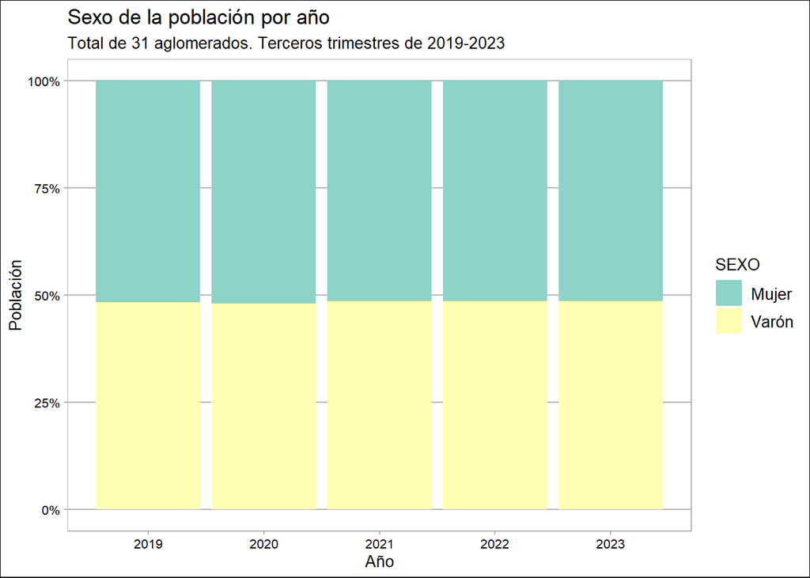

### Grupos etarios

Identificamos tres grupos etarios: de 16 a 30 años, de 31 a 50 y de 51 o más. El primer grupo ronda el 30% del total de la población de la muestra; el segundo y el tercero, entre el 33 y 36%

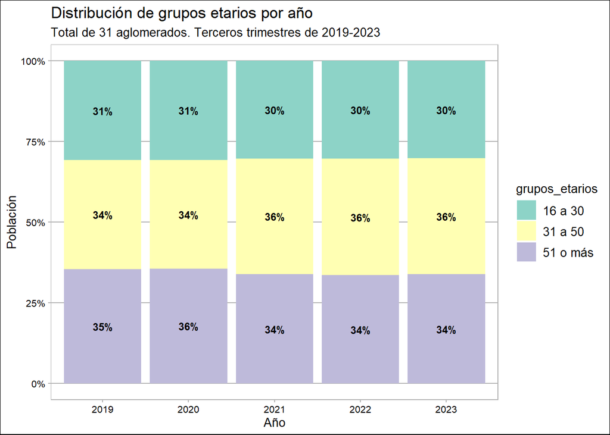

### Lugar de nacimiento

Entre un 82 y 85 % de la población trabaja en la misma provincia en la que nació. Los migrantes internos representan entre un 10 y 12%, mientras que la población migrante tiene una presencia todavía menor en los datos relevados: aproximadamente entre el 3 y el 5%, siendo en su mayoría proveniente de países limítrofes

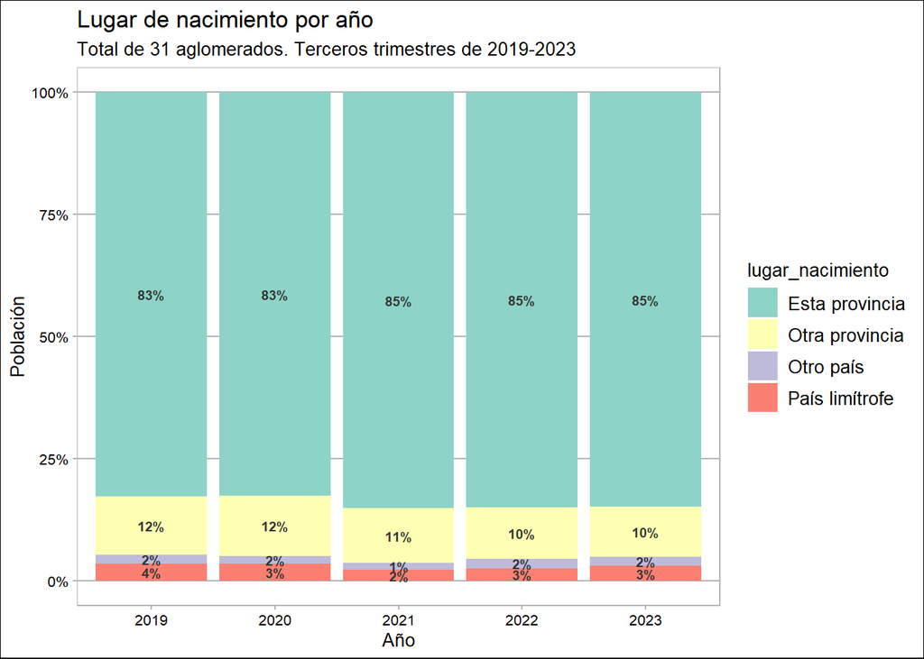

### Nivel educativo alcanzado

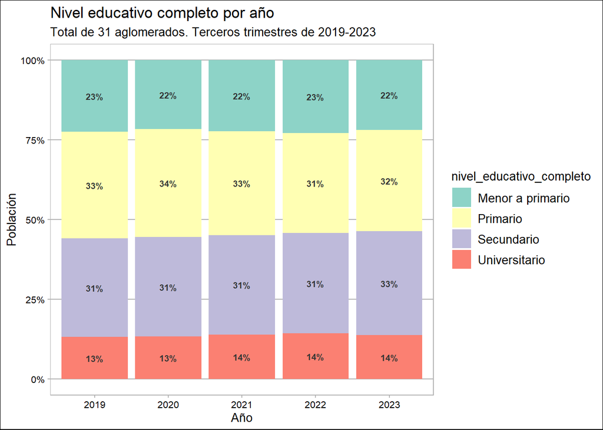

## Variables laborales

### Condición de actividad

El porcentaje de población ocupada se mantiene constante entre los años 2019 y 2021. Hacia 2023 la cantidad de población aumenta dos puntos porcentuales. La contraparte es la reducción de la población inactiva y desocupada.

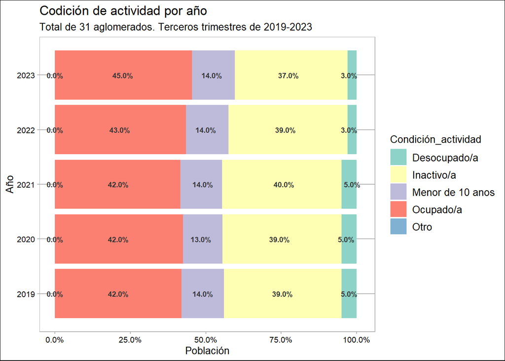

### Categoría ocupacional

Tras una contracción en el tercer trimestre de 2020 y 2021, la cantidad de asalariados en relación con el total de ocupados comenzó a crecer: hacia 2023 el 74,2% se los ocupados era asalariado. También la cantidad de ocupados/as que se define como patrón se incrementó levemente hacia 2023. Los ocupados por cuenta propia crecieron en términos absolutos y relativos entre 2019 y 2021; desde ese momento, su magnitud se mantuvo estable y se achicó sutilmente.

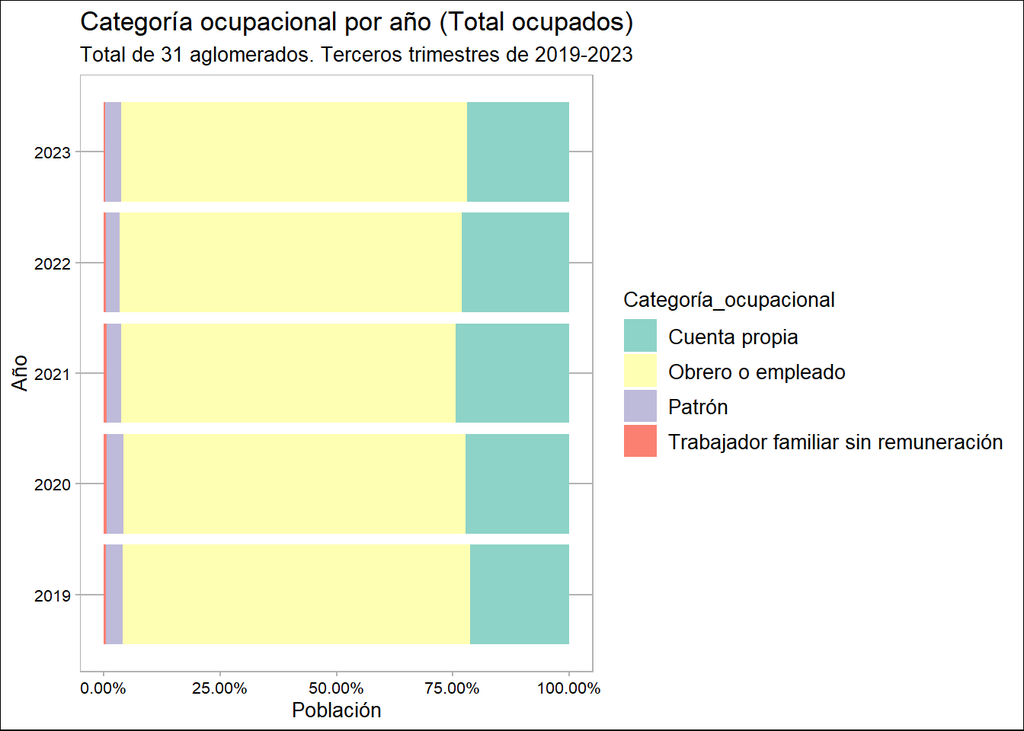

### Ámbito del establecimiento

La preeminencia de la ocupación en el sector privado en el período seleccionado es evidente, aunque es posible notar que entre 2019 y 2021 la proporción de ocupados/as en el sector público se incrementa mientras que en 2022 se contrae. En cuanto a las personas en actividad en el sector privado, la tendencia es creciente de 2021 en adelante.

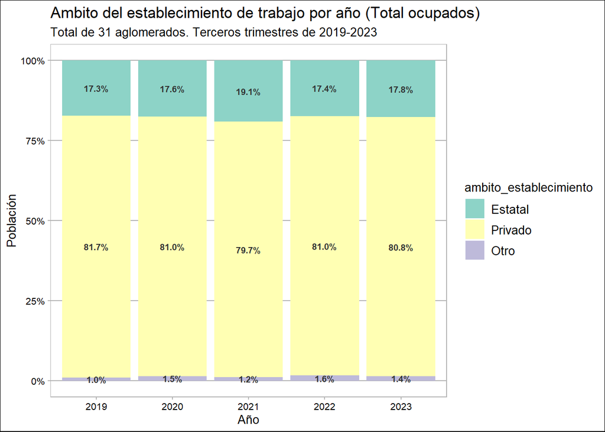

## Tasas básicas del Mercado de trabajo en el período 2019-2023

*(Los valores nos habían dado diferentes, más consistentes con los que publica el INDEC, no supimos por qué se nos cambiaron)*

**Principales tasas del mercado de trabajo. Total de 31 aglomerados urbanos. 3T-2019-2023**

| Año | Tasa de actividad | Tasa de inactividad | Tasa de empleo | Tasa de desocupación | Tasa de subocupación |
| --- | --- | --- | --- | --- | --- |
| 2019 | 47.0 | 52.8 | 42.3 | 10.1 | 11.8 |
| 2020 | 47.1 | 52.6 | 42.2 | 10.4 | 11.7 |
| 2021 | 46.3 | 53.3 | 41.6 | 10.2 | 11.9 |
| 2022 | 46.5 | 53.2 | 43.3 | 7.0 | 10.0 |
| 2023 | 48.3 | 51.5 | 45.0 | 6.9 | 9.4 |

* Elaboración propia en base a EPH-INDEC

### Tasas básicas desagregadas

#### Sexo

Complementariamente, es importante considerar que entre 2019 y 2023 la condición de desempleo es más extendida entre las mujeres, ubicándose entre 1 a 5 puntos porcentuales por encima del desempleo masculino.

La brecha de género más significativa se encuentra en relación a la condición de inactividad. En todos los años, **el porcentaje de inactividad para mujeres supera el de la ocupación, mientras que para varones ocurre el fenómeno contrario: la condición de ocupados siempre se mantiene por encima de la condición de inactividad.**

**Principales tasas del mercado de trabajo según sexo. Total de 31 aglomerados urbanos. 3T-2019-2023**

| Año | Sexo | Tasa de actividad | Tasa de inactividad | Tasa de empleo | Tasa de desocupación | Tasa de subocupación |
| --- | --- | --- | --- | --- | --- | --- |
| 2019 | Mujer | 39.8 | 60.0 | 35.3 | 11.2 | 14.3 |
|  | Varón | 54.7 | 45.0 | 49.7 | 9.2 | 9.8 |
| 2020 | Mujer | 40.4 | 59.3 | 35.9 | 11.2 | 13.7 |
|  | Varón | 54.3 | 45.3 | 49.0 | 9.7 | 10.0 |
| 2021 | Mujer | 39.0 | 60.8 | 34.2 | 12.3 | 13.7 |
|  | Varón | 54.0 | 45.5 | 49.4 | 8.5 | 10.6 |
| 2022 | Mujer | 40.1 | 59.6 | 36.8 | 8.3 | 12.5 |
|  | Varón | 53.3 | 46.4 | 50.1 | 5.9 | 8.0 |
| 2023 | Mujer | 41.8 | 58.1 | 38.5 | 7.8 | 11.6 |
|  | Varón | 55.1 | 44.6 | 51.7 | 6.1 | 7.6 |

* Elaboración propia en base a EPH-INDEC

#### Grupos etarios

El grupo etario de 16 a 30 años es el que tiene mayores tasas de desempleo en relación con los demás. Es llamativo que, a partir del año 2023, la tasa de inactividad en este grupo etario disminuya tres puntos porcentuales, al mismo tiempo que se incrementa su tasa de empleo.

**Principales tasas del mercado de trabajo según grupos etarios. Total de 31 aglomerados urbanos. 3T-2019-2023**

| Año | Grupos etarios | Tasa de actividad | Tasa de inactividad | Tasa de empleo | Tasa de desocupación | Tasa de subocupación |
| --- | --- | --- | --- | --- | --- | --- |
| 2019 | 16 a 30 | 56.4 | 43.3 | 45.5 | 19.3 | 13.9 |
|  | 31 a 50 | 83.6 | 16.1 | 77.9 | 6.8 | 11.0 |
|  | 51 o más | 43.7 | 56.1 | 41.3 | 5.6 | 10.8 |
| 2020 | 16 a 30 | 55.7 | 43.7 | 44.6 | 19.9 | 12.9 |
|  | 31 a 50 | 83.8 | 15.7 | 78.2 | 6.7 | 11.8 |
|  | 51 o más | 43.5 | 56.3 | 40.7 | 6.6 | 10.2 |
| 2021 | 16 a 30 | 55.5 | 44.0 | 44.7 | 19.5 | 13.7 |
|  | 31 a 50 | 83.6 | 16.0 | 77.9 | 6.8 | 11.6 |
|  | 51 o más | 43.8 | 55.9 | 41.0 | 6.4 | 10.7 |
| 2022 | 16 a 30 | 55.1 | 44.5 | 48.1 | 12.8 | 11.1 |
|  | 31 a 50 | 84.4 | 15.2 | 80.1 | 5.1 | 9.7 |
|  | 51 o más | 43.0 | 56.8 | 41.2 | 4.2 | 9.4 |
| 2023 | 16 a 30 | 58.1 | 41.5 | 50.1 | 13.7 | 10.7 |
|  | 31 a 50 | 85.8 | 14.0 | 81.9 | 4.6 | 8.7 |
|  | 51 o más | 44.9 | 54.9 | 43.3 | 3.6 | 9.4 |

* Elaboración propia en base a EPH-INDEC

#### Sexo y edad

Si analizamos la condición de actividad teniendo en cuenta tanto el sexo como el grupo etario, vemos que los varones y mujeres de 31 a 50 años representan un sector significativo dentro de la población ocupada en los años relevados (entre un 21 y un 28%).

**Distribución ocupados de acuerdo a sexo y grupos etarios**

| Año | Sexo | Grupo etario | Casos | Porcentaje |
| --- | --- | --- | --- | --- |
| 2019 | Mujer | 16 a 30 | 1219645 | 10.2 |
|  | Mujer | 31 a 50 | 2573045 | 21.6 |
|  | Mujer | 51 o más | 1360334 | 11.4 |
|  | Varón | 16 a 30 | 1819317 | 15.3 |
|  | Varón | 31 a 50 | 3137151 | 26.3 |
|  | Varón | 51 o más | 1813431 | 15.2 |
| 2020 | Mujer | 16 a 30 | 1230058 | 10.2 |
|  | Mujer | 31 a 50 | 2704692 | 22.5 |
|  | Mujer | 51 o más | 1384364 | 11.5 |
|  | Varón | 16 a 30 | 1793631 | 14.9 |
|  | Varón | 31 a 50 | 3106475 | 25.8 |
|  | Varón | 51 o más | 1804382 | 15.0 |
| 2021 | Mujer | 16 a 30 | 1129762 | 9.4 |
|  | Mujer | 31 a 50 | 2664597 | 22.3 |
|  | Mujer | 51 o más | 1256046 | 10.5 |
|  | Varón | 16 a 30 | 1795409 | 15.0 |
|  | Varón | 31 a 50 | 3376676 | 28.2 |
|  | Varón | 51 o más | 1739424 | 14.5 |
| 2022 | Mujer | 16 a 30 | 1335195 | 10.6 |
|  | Mujer | 31 a 50 | 2854587 | 22.7 |
|  | Mujer | 51 o más | 1298138 | 10.3 |
|  | Varón | 16 a 30 | 1862500 | 14.8 |
|  | Varón | 31 a 50 | 3488088 | 27.7 |
|  | Varón | 51 o más | 1733473 | 13.8 |
| 2023 | Mujer | 16 a 30 | 1440608 | 10.9 |
|  | Mujer | 31 a 50 | 2978164 | 22.6 |
|  | Mujer | 51 o más | 1376903 | 10.5 |
|  | Varón | 16 a 30 | 1927274 | 14.6 |
|  | Varón | 31 a 50 | 3563360 | 27.1 |
|  | Varón | 51 o más | 1874693 | 14.2 |

* Elaboración propia en base a EPH-INDEC

Asimismo, este grupo etario participa de manera significativa aunque secundaria de la población desocupada en comparación con el grupo etario de 16 a 30 años, tal como identificamos previamente.

Distribución de desocupados de acuerdo a sexo y grupos etarios

| Ano | Sexo | Grupo etario | Casos | Porcentaje |
| --- | --- | --- | --- | --- |
| 2019 | Mujer | 16 a 30 | 346473 | 26.0 |
|  | Mujer | 31 a 50 | 217602 | 16.3 |
|  | Mujer | 51 o más | 85957 | 6.5 |
|  | Varón | 16 a 30 | 382439 | 28.7 |
|  | Varón | 31 a 50 | 197913 | 14.9 |
|  | Varón | 51 o más | 102034 | 7.7 |
| 2020 | Mujer | 16 a 30 | 366842 | 26.3 |
|  | Mujer | 31 a 50 | 209789 | 15.1 |
|  | Mujer | 51 o más | 94288 | 6.8 |
|  | Varón | 16 a 30 | 383252 | 27.5 |
|  | Varón | 31 a 50 | 208884 | 15.0 |
|  | Varón | 51 o más | 130194 | 9.3 |
| 2021 | Mujer | 16 a 30 | 361556 | 26.7 |
|  | Mujer | 31 a 50 | 260916 | 19.3 |
|  | Mujer | 51 o más | 86605 | 6.4 |
|  | Varón | 16 a 30 | 348455 | 25.7 |
|  | Varón | 31 a 50 | 178561 | 13.2 |
|  | Varón | 51 o más | 118343 | 8.7 |
| 2022 | Mujer | 16 a 30 | 249758 | 26.5 |
|  | Mujer | 31 a 50 | 189803 | 20.2 |
|  | Mujer | 51 o más | 58378 | 6.2 |
|  | Varón | 16 a 30 | 218291 | 23.2 |
|  | Varón | 31 a 50 | 151923 | 16.1 |
|  | Varón | 51 o más | 73350 | 7.8 |
| 2023 | Mujer | 16 a 30 | 278385 | 28.7 |
|  | Mujer | 31 a 50 | 172814 | 17.8 |
|  | Mujer | 51 o más | 39199 | 4.0 |
|  | Varón | 16 a 30 | 257206 | 26.5 |
|  | Varón | 31 a 50 | 139530 | 14.4 |
|  | Varón | 51 o más | 82501 | 8.5 |

* Elaboración propia en base a EPH-INDEC

## La precariedad como fenómeno multidimensional

Para la construcción de un índice de precariedad, rastreamos un conjunto de situaciones presentes en la EPH que nos permiten dar cuenta de diferentes dimensiones del fenómeno. Tal como plantea [Mariana Fernández Massi](https://doi.org/10.15446/cuad.econ.v33n62.43675), las características de la fuente estadística permiten referir a la **precarización del empleo** y no a otras aristas igualmente importantes como las dimensiones subjetivas vinculadas a la precarización del trabajo (riesgos psicosociales, satisfacción en el trabajo, utilización de los saberes, entre otras) y las dimensiones colectivas asociadas con las capacidades de acción y representación ante un daño a los derechos laborales.

### Operacionalizando la precariedad laboral

Asignamos un peso específico a cada una de esas dimensiones y, al mismo tiempo, a los distintos indicadores que componen cada dimensión. En la figura a continuación es posible observar esta distribución.

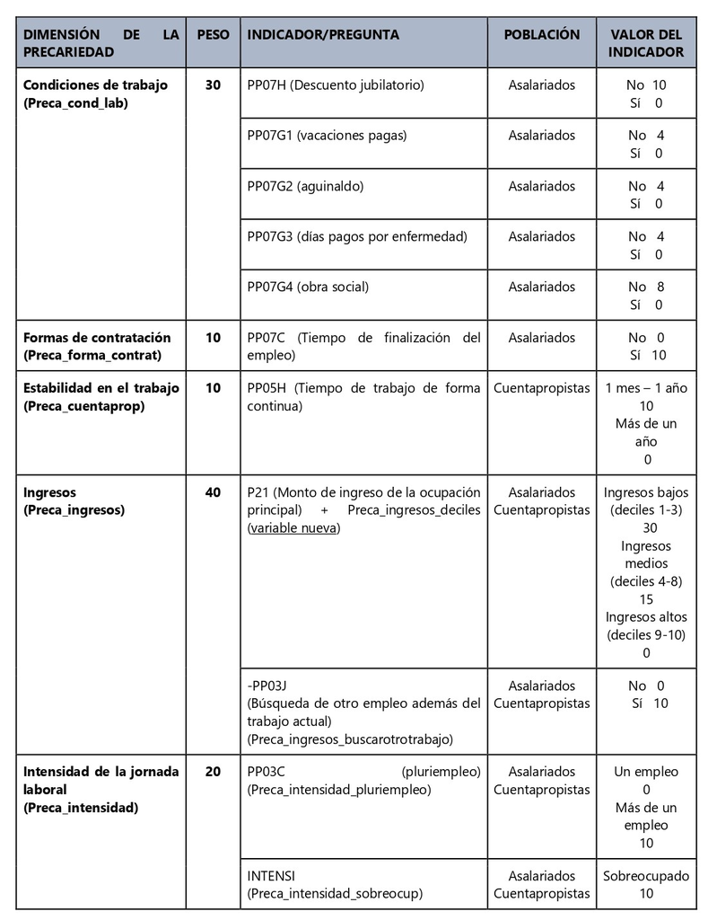

#### Precarización en las condiciones laborales

Tomamos en consideración, como item principal, la presencia o ausencia de descuento jubilatorio y, luego, otros derechos laborales que usualmente están correlacionados al anterior. Es decir, allí donde no hay descuento jubilatorio muy probablemente no hay tampoco vacaciones pagas, aguinaldo, obra social y días pagos por enfermedad.

#### Precarización en las formas de contratación

Esta dimensión abarca solo a ocupados asalariados. Como aproximación empírica utilizamos la pregunta “Ese empleo tiene tiempo de finalización?”. Consideramos que esta forma de precariedad existe toda vez que la respuesta es afirmativa.

#### Inestabilidad en el trabajo

Dado que quisimos construir un índice de precariedad válido tanto para asalariados como para trabajadores por cuenta propia, buscamos una aproximación equivalente al tiempo de finalización del empleo. Optamos por seleccionar la pregunta “¿Durante cuánto tiempo ha estado trabajando en ese empleo en forma continua? (con interrupciones laborales no mayores de 15 días)”. Consideramos que esta forma de precariedad existe cuando la persona lleva menos de un año de permanencia en ese trabajo.

#### Precariedad en los ingresos

Para trabajar esta dimensión tomamos la pregunta en la que se declara el monto de los ingresos percibidos por la ocupación principal de la persona. Este interrogante abarca a la población ocupada asalariada y a la cuentapropista.

Debido a la alta tasa de no respuesta en esta pregunta, imputamos a los casos perdidos un valor equivalente a la media del ingreso declarado por las demás personas con las que compartían una serie de características: sexo, grupo etario, región y sector de actividad. Una vez imputados esos valores, armamos deciles por año para poder ubicar a cada caso. Consideramos que quienes se ubican en los deciles 1 a 3 tienen ingresos bajos, quienes se ubican en los deciles 4 a 8 tienen ingresos medios y, finalmente, a los deciles 9 y 10 les corresponden ingresos altos.

```
##
##        Ingresos bajos Ingresos medios Ingresos altos
##   2019           7287           11375           4417
##   2020           6853            9434           3924
##   2021           5518            9029           3635
##   2022           6651            9694           4036
##   2023           6190           10415           4017
```

La otra subdimensión considerada para analizar la precariedad de los ingresos buscó captar si las personas buscaban activamente otro trabajo. Si bien esto puede ocurrir por diferentes razones (insatisfacción en el trabajo, cambios en los proyectos vitales, entre otros motivos) asumimos que un ingreso insuficiente puede empujar dicha búsqueda. Por lo tanto, contemplamos que haber respondido afirmativamente a esta pregunta refuerza una condición de precariedad en relación a los ingresos.

#### Precarización por la intensificación de la jornada jornada laboral

Finalmente, para analizar esta dimensión sopesamos, por un lado, si las personas estaban pluriempleadas (si declaraban tener uno o más empleos); por otro, si en la variable INTENSI estaba calificado como sobreocupado/a. Ambas subdimensiones involucran a asalariados y a cuentapropistas.

### Precariedad total

Llamamos **precariedad_total** a la variable que resume las demás formas de precariedad. Dintinguimos tres niveles de precariedad (bajo, medio y alto) que se desprende de la sumatoria de valores que cada caso obtiene en los diferentes tipos de precariedad.

### Análisis de la precariedad

Veamos la distribución de la precariedad total y de sus componentes entre los años 2019 y 2023.

#### Precariedad total

**Niveles de precariedad laboral según año. Total de ocupados asalariados y cuentapropistas (31 aglomerados urbanos). 3T-2019-2023**

| Año | Precariedad baja | Precariedad media | Precariedad alta | NA |
| --- | --- | --- | --- | --- |
| 2019 | 12205 | 7474 | 3356 | 44 |
| 2020 | 10439 | 6454 | 3289 | 29 |
| 2021 | 9616 | 5762 | 2771 | 33 |
| 2022 | 10612 | 6787 | 2956 | 26 |
| 2023 | 10762 | 7046 | 2762 | 52 |

* Elaboración propia en base a EPH-INDEC

#### Tipos de precariedad por año

Es destacable que el año 2020 sea el que arroja valores máximos de precariedad por ingreso. Cabe aclarar que aquí hemos considerado precarios a quienes tenían salarios bajos (deciles 1 a 3).

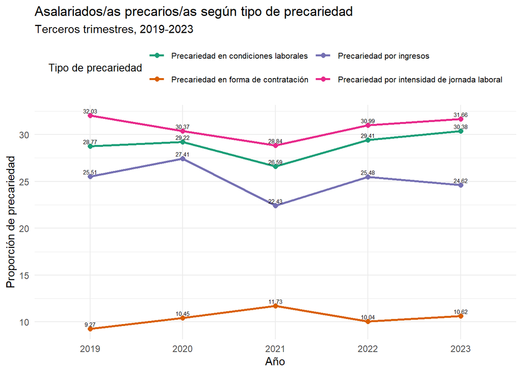

La situación es algo diferente si indagamos lo que ocurre con los/as trabajadores/as por cuenta propia. Por la forma propia del trabajo, las intermitencias laborales son más frecuentes que en el caso de los asalariados; esto se puede observar cuando comparamos lo que sucede con la Precariedad por inestabilidad laboral (cuentapropistas) con la Precariedad en la forma de contratación (asalariados). Para 2021, uno de cada cuatro trabajadores/as por cuenta propia estaba alcanzado por esta condición.

En relación con la precariedad por ingresos, los valores son sustancialmente mayores en el caso de trabajadores/as por cuenta propia. En el tercer trimestre de 2020, casi la mitad se ubicaba en el grupo de ingresos bajos (deciles 1 a 3).

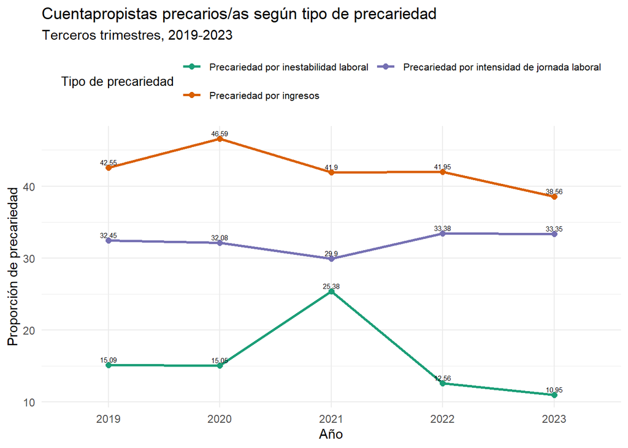

#### Niveles de precariedad por sexo y grupo etario

Al segmentar el análisis por sexo y grupo etario encontramos que, en todos los grupos etarios, la proporción de mujeres con niveles de precariedad alta o media es mayor que en el caso de los varones.

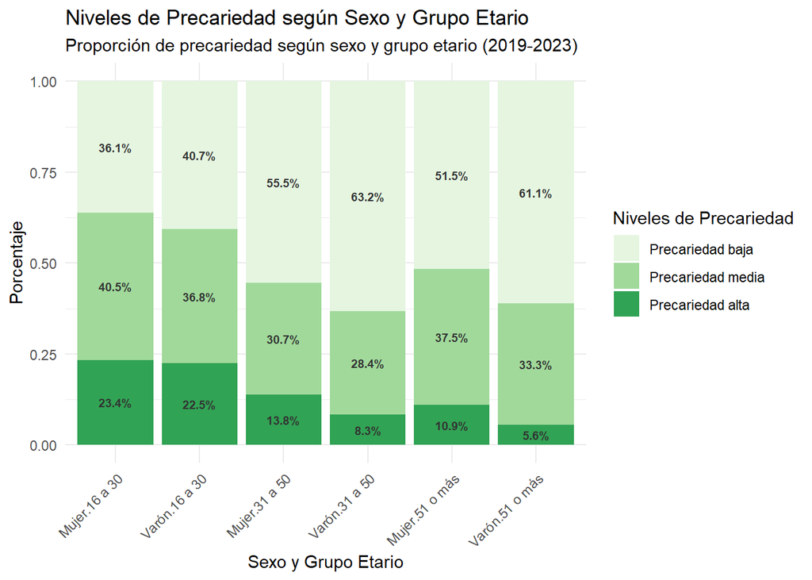

#### Niveles de precariedad según lugar de nacimiento

Analizando los niveles de precariedad según lugar de nacimiento encontramos que la distribución es similar en general, pero los niveles medio y alto tienen mayor relevancia en el caso de los migrantes de países limítrofes; seis de cada 10 ocupados/as se ubican en alguna de estas categorías.

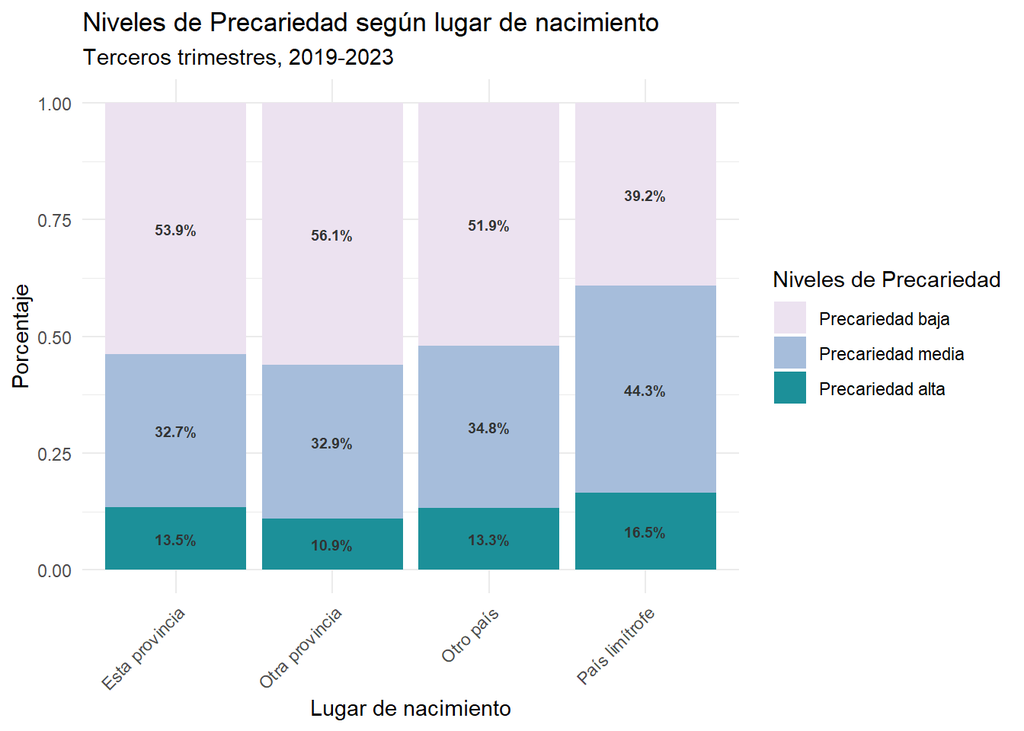

#### Niveles de precariedad según nivel educativo

El entrecruzamiento entre nivel educativo y niveles de precariedad arroja como resultado una relación inversamente proporcional entre ambas variables. Así, siete de cada diez personas que no han completado el nivel primario tienen niveles medios o altos de precariedad; a la vez que dos personas cada diez que completaron el nivel universitario se concentran en esas categorías.

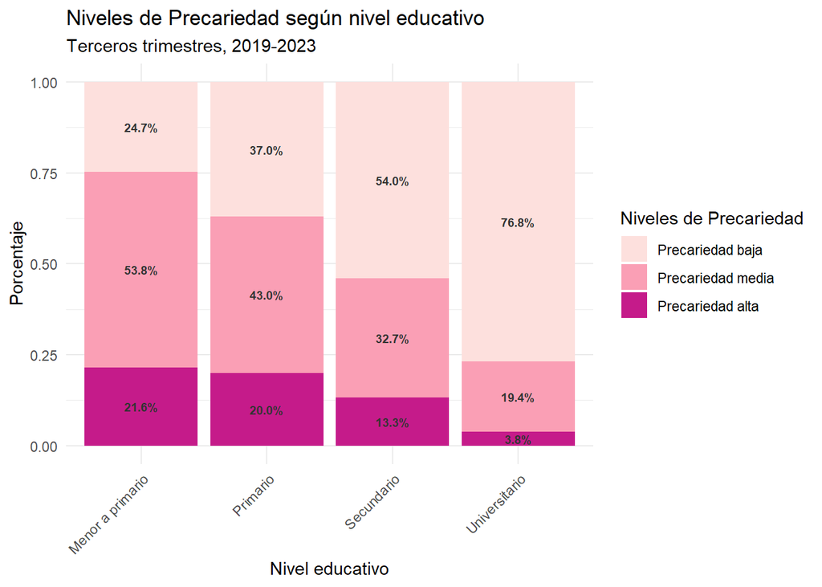

#### Niveles de precariedad según ámbito de establecimiento

**Niveles de precariedad laboral según ámbito de establecimiento. Total de ocupados asalariados y cuentapropistas (31 aglomerados urbanos). 3T-2019-2023**

| Ambito | Tipo de precariedad | Casos | Proporción |
| --- | --- | --- | --- |
| Estatal | Precariedad baja | 9022048 | 82.183957 |
|  | Precariedad media | 1506917 | 13.726861 |
|  | Precariedad alta | 448905 | 4.089181 |
| Privado | Precariedad baja | 22274773 | 47.032582 |
|  | Precariedad media | 17858167 | 37.707038 |
|  | Precariedad alta | 7227362 | 15.260380 |
| Otro | Precariedad baja | 397780 | 48.706781 |
|  | Precariedad media | 262611 | 32.155806 |
|  | Precariedad alta | 156292 | 19.137413 |

* Elaboración propia en base a EPH-INDEC

Amerita, sin embargo, revisar qué ocurre con cada uno de los tipos de precariedad que identificamos.

Mientras que hay valores en los que asalariados/as del ámbito público y privado se encuentran lejos (precarización en las condiciones de trabajo) hay otros en los que están más cerca (precarización por la intensidad de la jornada laboral, precarización en las formas de contratación).

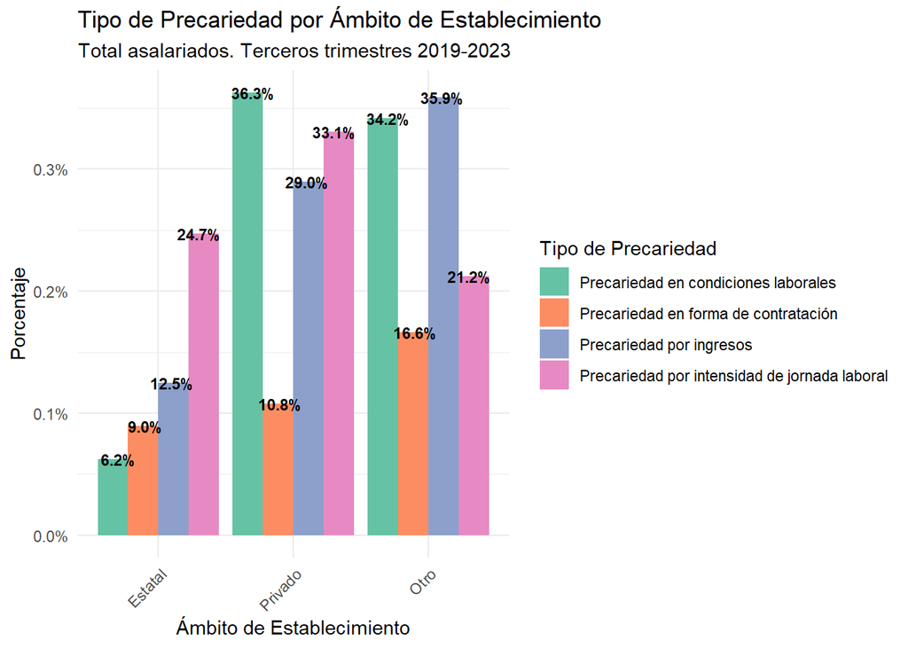

Si indagamos en los trabajadores/as por cuenta propia, quienes se desempeñan en el sector privado, encontramos una mayor incidencia de la precariedad por ingresos en comparación con los asalariados. En los demás tipos de precariedad, también existen diferencias entre ambos grupos de trabajadores/as.

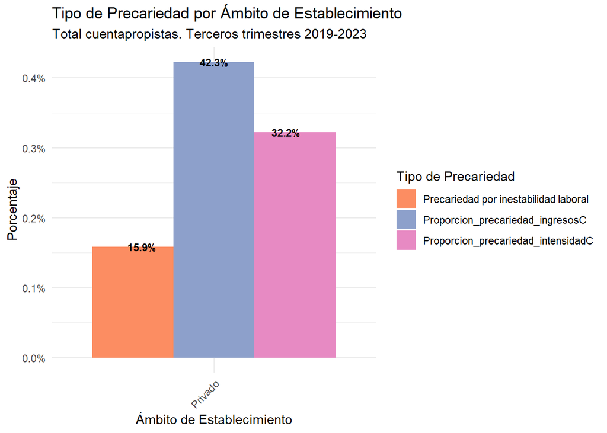

#### Niveles de precariedad según sector de actividad

La apertura por sectores de actividad nos permite distinguir un grupo en el que los niveles altos de precariedad superan el 20% del total de ocupados/as: Construcción, Servicio doméstico y Hoteles y restaurantes. Le sigue de cerca el sector Comercio. Los valores más bajos aparecen en la Administración pública y en Enseñanza (donde existe mayor prevalencia del sector público que del privado).

En relación con los niveles medios de precariedad, casi la mitad de los/as ocupados precarios/as de los sectores de Comercio, Construcción, Servicio Doméstico, Hoteles y restaurantes y Otros servicios sociales y comunitarios se encuentran en este grupo.

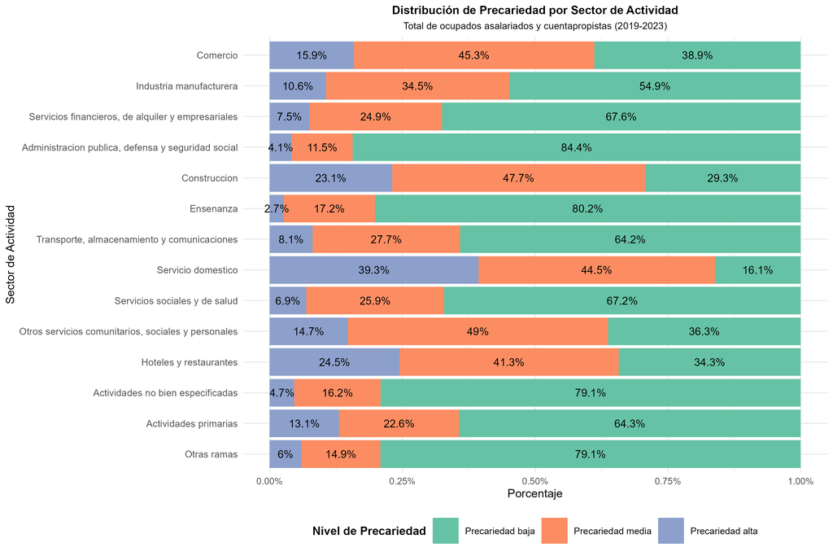

Un último ejercicio en relación con los sectores consistió en evaluar cuáles tenían ocupados/as con valor “0” en precariedad_total. Esto arrojó los siguientes resultados:

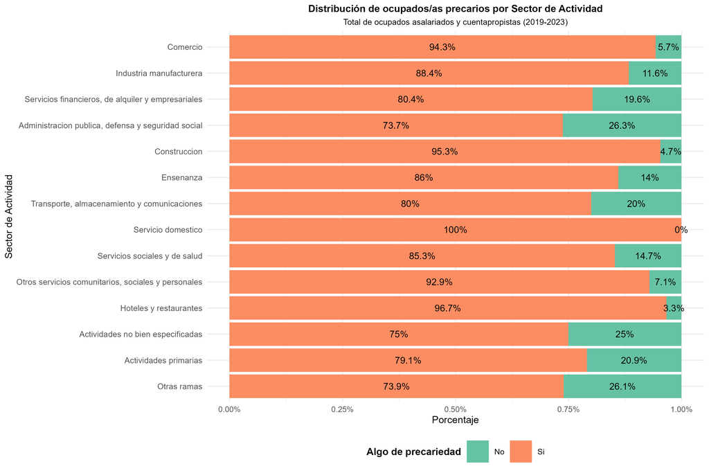